# Bruhn_A13_2

ストリンガー 1:

$$y_1 = 4 + .39 = 4.39$$

$$x_1 = -33.15 + 15.74 = -17.41$$

$$\sigma_b = -\frac{M_y y}{I_x} - \frac{M_x x_1}{I_y}$$

$$\sigma_b = -\frac{713000 \times 4.39}{186.46} - \frac{(-38000 \times -17.41)}{431.7} = -18330\#/\text{in}^2.$$

ストリンガー 9:

$$y_9 = 6.89, \quad x_9 = 15.39$$

$$\sigma_b = -\frac{713000 \times 6.89}{186.46} - \frac{(-38000 \times 15.39)}{431.7} = -25000\#/\text{in}^2.$$

### 例題 3

前の例題は曲げ応力方程式に代入することで解かれた。学生は、梁の断面における内部抵抗モーメントと同じ断面における外部曲げモーメントを等しくすることによって、曲げ応力問題を解くべきである。説明のために、図 A13.6 に単純支持された荷重梁を示す。与えられた梁の荷重に対するせん断力図および曲げモーメント図も示されている。図 A13.7 は、スパン全体にわたって一定である梁の断面を示している。

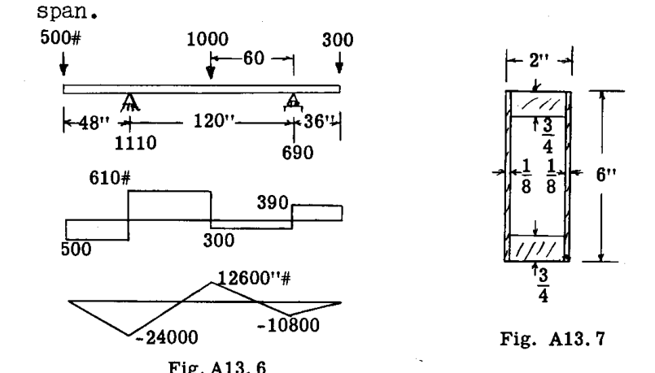

図 A13.6, 図 A13.7

最大曲げモーメントは左支持点の上で発生し、 $-24000\text{ in. lbs.}$ に等しい。梁断面の対称性により、図心を通過する水平軸は梁の高さの中心線であり、したがって中立軸は梁の中点にある。

図 A13.8 は、左端から左支持点の上方で曲げモーメントが最大となる断面までの梁のその部分の自由体を示している。三角形状の曲げ応力分布図は、最も外側の繊維での値が $\sigma_b$ であるカット断面に作用している。力 $T_A, T_B$ などは、それぞれ図 A13.9 でAおよびBとラベル付けされた梁断面エリア上の全荷重を表している。部分Aの下端における応力強度は $\sigma_b (2.25/3) = 0.75 \sigma_b$ である。

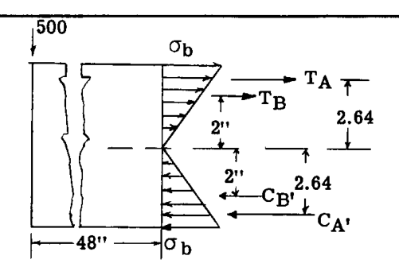

図 A13.8, 図 A13.9

$$T_A = C_A' = \text{平均応力} \times \text{面積}$$

$$= \left(\frac{\sigma_b + 0.75\sigma_b}{2}\right) (1.75 \times 0.75) = 1.15\sigma_b$$

中立軸から部分Aの台形応力荷重の図心までの距離は $2.64\text{ インチ}$ である。同様に、

$$T_B = C_B' = \left(\frac{0 + \sigma_b}{2}\right) 3 \times 0.25 = 0.375\sigma_b$$

$T_B$ へのアームは $0.667 \times 3 = 2\text{ インチ}$ である。

梁の自由体の平衡のために、点（O）のまわりのモーメントをとり、ゼロに等しくする。

$$\sum M_O = -500 \times 48 + 2.64 \times T_A + 2.64 \times C_A' + 2 \times T_B + 2 \times C_B' = 0$$

$T_A, T_B$ などについて求めた値を代入すると、

$$-500 \times 48 + 2.64 \times 1.15\sigma_b + 2.64 \times 1.15\sigma_b + 2 \times 0.375\sigma_b + 2 \times 0.375\sigma_b = 0$$

したがって

$$\sigma_b = \frac{24000}{7.58} = 3170\text{ psi}.$$

### 曲げ応力公式を用いた解法

$$\sigma_b = \frac{M c}{I}$$

ここで、 - $M = -24000$ - $c = 3\text{"}$ - $I = \text{中立軸まわりの慣性モーメント}$

### $I$ の計算

部分AおよびA’について：

$$I = \frac{1}{12} \times 1.75 \times (6^3 - 4.5^3) = 18.26\text{ in.}^4$$

ウェブ部分b, b"について：

$$I = \frac{1}{12} \times 0.25 \times 6^3 = 4.50\text{ in.}^4$$

$$I_{\text{Total}} = 22.76\text{ in.}^4$$

したがって、

$$\sigma_b = -\frac{24000 \times 3}{22.76} = -3170\text{ psi},$$

これは最初の解と一致する。

### 例題 4

図 A13.10 は荷重された梁を示し、図 A13.11 は断面a-a’における梁の断面を示している。与えられた梁の荷重下で、断面a-a’における最大曲げ応力の大きさを求めよ。梁の断面は、水平な図心軸に対して非対称である。簡単な計算により、図 A13.11 に示すように中立軸の位置が特定される。

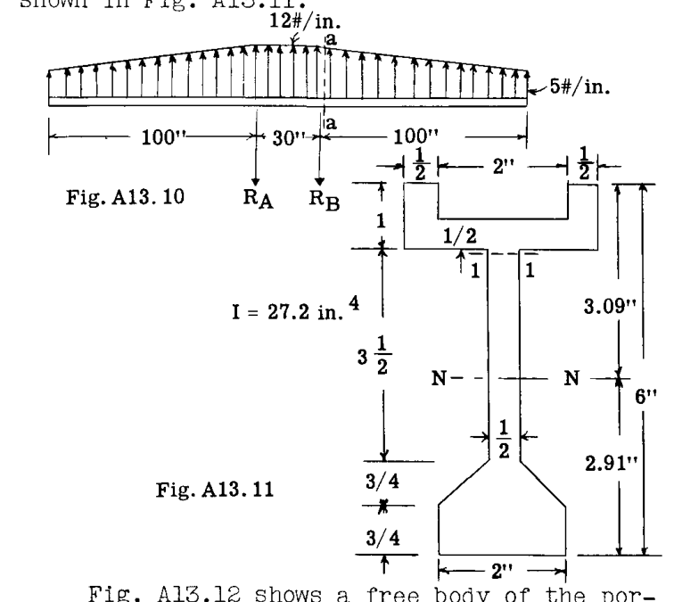

図 A13.10, 図 A13.11

図 A13.12 は、断面a-aの右側にある梁の部分の自由体を示している。曲げ応力強度図は、断面a-aにおける梁の面に作用する水平な矢印で示されている。図 A13.13 は、断面a-aにおける梁の断面を示している。

一般的な手順は、断面の各部分1から6における全曲げ応力荷重を決定し、次に中立軸まわりのこれらの各荷重のモーメントを決定することであり、その合計は外部曲げモーメントに等しくなければならない。

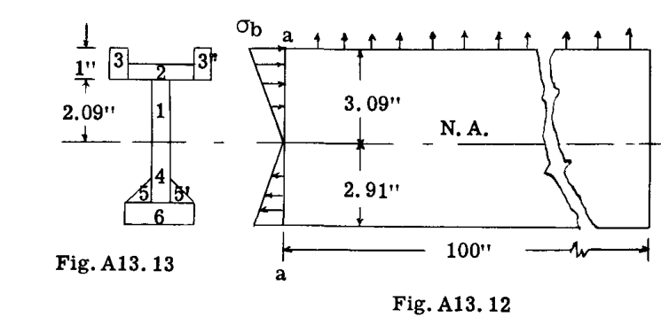

図 A13.12, 図 A13.13

この解決方法は、曲げ応力公式に代入するよりも多くの計算を必要とするが、学生はこの解決方法から内部力の作用についてより良い理解を得るはずである。非均質な梁や弾性限度を超えて応力を受ける梁を解決する場合、単純な梁曲げ応力公式を導出できないため、この解決方法はしばしば必要または有利であることが証明される。

図 A13.12 において、最も遠い繊維、すなわち中立軸から $3.09\text{"}$ 上方の繊維における強度を $\sigma_b$ とする。表 Aは、断面の各部分における全応力と中立軸まわりのそれらのモーメントの計算を、すべて未知の応力 $\sigma_b$ で表して示している。

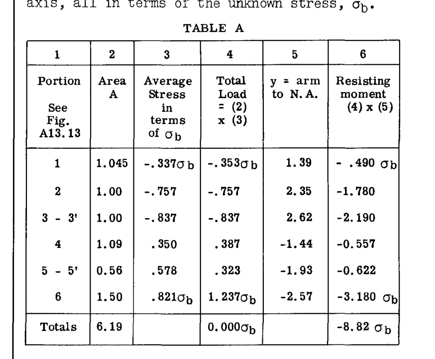

TABLE A

### 表 Aの説明

第3列は、6つの各部分における平均応力を示している。例えば、部分（1）の応力は、中立軸でのゼロから、部分（1）の上端における

$$\frac{2.09}{3.09}\sigma_b = .674\sigma_b$$

まで変化する。したがって、平均応力は

$$\frac{.674\sigma_b + 0}{2} = .337\sigma_b$$

である。部分3または3’では、下端の応力 $= .674\sigma_b$ 、上端の応力 $= \sigma_b$ である。

したがって、平均応力は

$$\frac{(1 + .674)}{2}\sigma_b = .837\sigma_b$$

である。第5列は、中立軸から各ブロックの荷重の図心までの距離である。部分（1）について、応力パターンは三角形であり、

$$y = \frac{2}{3} \times 2.09 = 1.39\text{"}$$

である。部分（2）、（3）、（5）および（6）について、曲げ応力分布は台形であり、アームはこの台形の図心までである。

表 Aからの全内部抵抗モーメント $-8.82\sigma_b$ は、外部曲げモーメント $36670\text{ in-lbs}$ に等しい。したがって、

$$\sigma_b = -\frac{36670}{8.82} = -4160\#/\text{in.}^2.$$

平衡のために、梁断面の全圧縮応力は全引張応力に等しくなければならない、すなわち $\sum H$ はゼロに等しくなければならない。表 Aの第4列は、断面の各部分における全荷重を与えており、この列の合計はゼロである。

断面の下部繊維における曲げ応力は、中立軸からの距離に正比例する、すなわち、

$$\sigma_{b\text{ lower}} = \frac{2.91}{3.09} \times 4160 = 3930\#/\text{in.}^2$$

### 曲げ応力公式を用いた解法

$$\sigma_b = -\frac{M y}{I_{\text{N.A.}}} \quad I_{\text{N.A.}} = 27.2\text{ in.}^4$$

したがって、

$$\sigma_b (\text{upper fiber}) = -\frac{36670 \times 3.09}{27.2} = -4160\text{ psi}.$$

これは上記の解と一致する。

## A13.9 非均質断面を持つ梁の曲げ応力、弾性範囲内の応力

一般に、梁は通常1つの材料で作られているが、梁の断面を形成するために2つの異なる材料が使用される特別なケースがしばしば発生する。例えば、商用航空機はその寿命の中で、追加の装備、固定機器、より大きなエンジンなどの追加や変更など、多くの変更や改造をしばしば受ける。この航空機重量の増加は構造応力を増加させ、臨界応力点において様々な構造部材を補強することがしばしば必要になる。スペースの制限は通常重要であるため、補強材料は元の材料よりも剛性が高いことがしばしば必要とされる。何年も前、トウヒ材が翼梁の一般的な材料であったとき、補強材のサイズを小さくするために、カエデのようなより剛性の高い木材を臨界応力点で補強材として使用するのが通常のやり方であった。アルミ合金の梁では、鋼はアルミ合金よりも $29000000 / 10500000$ 、すなわち $2.76$ 倍剛性が高いため、熱処理された合金鋼の補強材がしばしば使用される。

### 換算断面法による解法

複合梁における応力がどのように決定されるかを説明するために、2つの例題を提示する。

### 例題 5

図 A13.14 は、すべてトウヒ材である元の梁の断面を示している。図 A13.15 は、補強または改造された梁の断面を示している。示されているように、カエデ材の2つの耳が上部に追加され、鋼製のストラップが梁の下部に追加されている。問題は、梁の断面が、上部梁部分に圧縮を引き起こす水平軸まわりの $60000\text{ in. lbs.}$ の外部曲げモーメントを受けるときに、梁断面の上部および下部における応力を求めることである。3つの異なる材料の弾性係数（E）は以下の通りである：

- $E_{\text{spruce}} = 1,300,000\text{ psi}.$
- $E_{\text{maple}} = 1,600,000\text{ psi}.$
- $E_{\text{steel}} = 29,000,000\text{ psi}.$

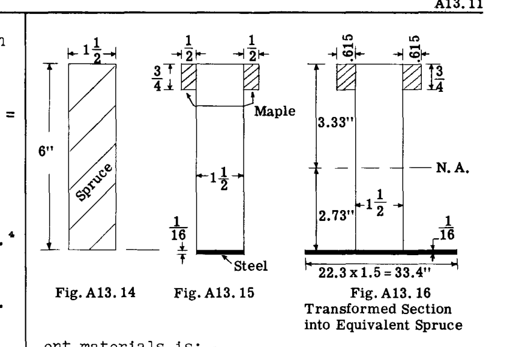

図 A13.14, 図 A13.15, 図 A13.16

### 解法

解決の最初のステップは、図 A13.15 の補強された梁の断面を、全体が同じ材料で構成された同等の梁の断面に変換することである。これは、各材料の弾性係数がその材料の剛性の尺度を与えるため、可能である。この解法では、補強された梁は、図 A13.16 に示すようにトウヒの梁の断面に変換される。

$$\frac{E_{\text{maple}}}{E_{\text{spruce}}} = \frac{1,600,000}{1,300,000} = 1.23$$

$$\frac{E_{\text{steel}}}{E_{\text{spruce}}} = \frac{29,000,000}{1,300,000} = 22.3$$

したがって、図 A13.15 のカエデの補強材をトウヒに変換するために、図 A13.16 に示すように、各ストリップの幅を $1.23 \times 0.5 = 0.615\text{ インチ}$ に増やす。同様に、鋼の補強材をトウヒに変換するために、図 A13.16 に示すように、幅を $22.3 \times 1.5 = 33.4\text{ インチ}$ にする。

この変換された同等断面は、材料の弾性限度内で応力を受ける均質な梁断面と同様に扱われる。通常の計算により、中立軸が図のように配置され、中立軸まわりの変換された断面の慣性モーメントは $51.30\text{ in.}^4$ の値を与える。

梁断面の上端における曲げ応力：

$$\sigma_{b_c} = -\frac{M_x y}{I_x} = -\frac{60000 \times 3.33}{51.30} = -3900\text{ psi}.$$

図 A13.16 の変換された梁断面の下端における曲げ応力は次のようになる：

$$\sigma_{b_t} = -\frac{60000 \times (-2.73)}{51.30} = 3200\text{ psi}.$$

したがって、鋼製補強ストラップの応力は、 $22.3 \times 3200 = 71500\text{ psi}$ に等しい。

これらすべての応力は3つの材料の弾性限度内であるため、使用された梁曲げ応力公式が適用可能である。

### 例題 6

図 A13.17 は、面積が等しく、薄いウェブで接続された4つのストリンガーa, b, c, dからなる非対称な梁の断面を示している。この例題ではウェブは無視される。各ストリンガーは、図 A13.17 に示すように異なる材料で作られている。梁断面は、図示のように曲げモーメント $M_x$ および $M_y$ を受ける。これらの加えられた外部曲げモーメントに抵抗する際の、各ストリンガーにおける応力と全荷重を決定することが要求される。

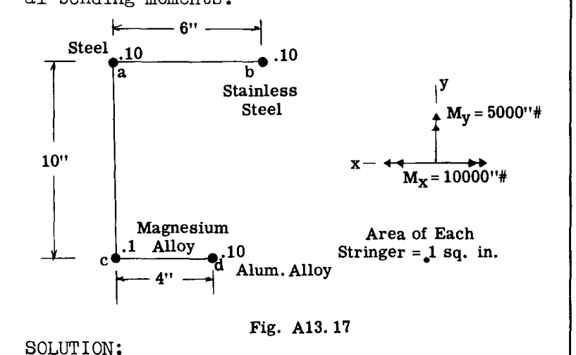

図 A13.17

### 解法

4つのストリンガーは異なる材料で作られているため、すべての材料を、4つのストリンガーすべてがマグネシウム合金である同等の梁の断面に変換する。

- $E_{\text{mag.}} = 6,500,000$
- $E_{\text{steel}} = 29,000,000 \quad \frac{E_{\text{steel}}}{E_{\text{mag.}}} = \frac{29}{6.5} = 4.46$
- $E_{\text{stain. steel}} = 28,000,000 \quad \frac{E_{\text{S.S.}}}{E_{\text{mag.}}} = \frac{28}{6.5} = 4.31$
- $E_{\text{alum. alloy}} = 10,500,000 \quad \frac{E_{\text{alum.}}}{E_{\text{mag.}}} = \frac{10.5}{6.5} = 1.615$

上記のように剛性値の比率を使用すると、すべての材料がマグネシウムになった図 A13.18 の変換された梁断面が得られる。それぞれの元の面積 $0.1\text{ sq. in.}$ に、これらの剛性比率の値を掛け合わせている。

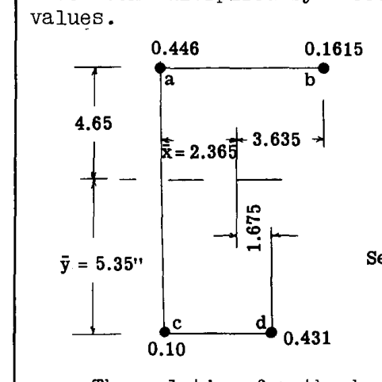

図 A13.18

図 A13.18 の梁断面に対する解法は、他の非対称な均質梁断面に対するものと同じである。

最初のステップは、この断面の図心を特定し、図心軸XおよびYまわりのこの断面の慣性モーメントを決定することである。

$$\bar{y} = \frac{\sum A y}{\sum A} = \frac{.446 \times 10 + 0.1615 \times 10}{1.1385} = 5.35\text{"}$$

$$\bar{x} = \frac{\sum A x}{\sum A} = \frac{0.1615 \times 6 + .431 \times 4}{1.1385} = 2.365\text{"}$$

$$I_x = 0.6075 \times 4.65^2 + 0.531 \times 5.35^2 = 28.27\text{ in.}^4$$

$$I_y = 0.546 \times 2.365^2 + 0.165 \times 3.635^2 + 0.431 \times 1.635^2 = 6.34\text{ in.}^4$$

$$I_{xy} = 0.446 (-2.365)(4.65) = -4.90$$

$$0.1615 \times 3.635 \times 4.65 = 2.73$$

$$0.10 (-2.365)(-5.35) = 1.27$$

$$0.431 \times 1.635 (-5.35) = -3.77$$

$$\text{TOTAL} = -4.67\text{ in.}^4 = I_{xy}$$

曲げ応力は、Art. A13.5のメソッド3を使用して計算される。

Art. A13.5の式（14）より、

$$\sigma = -(K_3 M_y - K_1 M_x)x - (K_2 M_x - K_1 M_y)y$$

$$K_1 = \frac{I_{xy}}{I_x I_y - I_{xy}^2} = \frac{-4.67}{28.27 \times 6.34 - 4.67^2}$$

$$= \frac{-4.67}{157.4} = -0.0296$$

$$K_2 = \frac{I_y}{I_x I_y - I_{xy}^2} = \frac{6.34}{157.4} = 0.0403$$

$$K_3 = \frac{I_x}{I_x I_y - I_{xy}^2} = \frac{28.27}{157.4} = 0.1797$$

$$M_x = -10,000\text{ in. lb.} \quad M_y = 5000\text{ in. lb.}$$

ストリンガー（c）について考える：

$$x = -2.365, \quad y = -5.35$$

$\sigma_b$ 方程式に代入すると、

$$\sigma_c = - \left[ 0.1797 \times 5000 - (-0.0296)(-10000) \right] x - \left[ (0.0403)(-10000) - (-0.0296 \times 5000) \right] y$$

$$= - (898 - 296)x - \left[ (-403) + 148 \right] y$$

$$\sigma_c = -602x + 255y \quad \text{--- (18)}$$

ストリンガー（c）について $x = -2.365, y = -5.35$ したがって、

$$\sigma_c = -602(-2.365) + 255(-5.35)$$

$$= 1423 - 1360 = 63\text{ psi}.$$

したがって、ストリンガー（c）の全荷重 $P_c$ は、

$$\sigma_c (\text{面積}) = 63 \times 0.1 = 6\text{ lbs. 引張}.$$

ストリンガー（a）について：

$$x = -2.365, \quad y = 4.65$$

式（18）より、

$$\sigma_a = -602(-2.365) + 255 \times 4.65 = 2613\text{ psi}.$$

$$P_a = 2613 \times 0.446 = 1167\text{ lb. 引張}.$$

このストリンガーの真の面積は $0.1\text{平方}$ であるため、この鋼製ストリンガーの応力は、

$$1167 / 0.1 = 11670\text{ psi 引張}.$$

ストリンガー（b）について：

$$x = 3.635, \quad y = 4.65$$

$$\sigma_b = -602 \times 3.635 + 255 \times 4.65 = -1006\text{ psi}.$$

$$P_b = -1006 \times 0.1615 = -162\text{ lbs.}$$

ステンレス鋼ストリンガーの真の応力は次のようになる：

$$= -162 / 0.1 = -1628\text{ psi}.$$

ストリンガー（d）について：

$$x = 1.635, \quad y = -5.35$$

$$\sigma_d = -602 \times 1.635 + 255(-5.35) = -2345\text{ psi}.$$

$$P_d = -2345 \times 0.431 = -1010\text{ lbs.}$$

$$\text{真の応力} = -\frac{1010}{0.1} = -10100\text{ psi}.$$

結果を検証するために、全ストリンガー荷重がゼロに等しくなるか確認する。

$$\sum P = 6 + 1167 - 162 - 1010 = 1\text{ 確認}.$$

さらに、XおよびY軸まわりのストリンガー荷重のモーメントは、加えられた外部曲げモーメントに等しくなければならない。

ストリンガー（a）と（c）を通過するY軸まわりのモーメントをとる。

$$\sum M_y = -6 \times 162 - 4 \times 1010 + 5000 = -12\text{ in. lb.}$$

ストリンガー（c）と（d）を通過するX軸まわりのモーメントをとる。

（この例題における計算は計算尺で行われているため、正確な確認は得られない。）

## A13.10 弾性限度応力範囲を超えて応力を受ける均質梁の曲げ

構造用航空機の設計において、航空機に加えられる荷重は、永久ひずみを受けることなく構造によって支えられなければならない。これは応力が弾性範囲内にあるべきであることを意味する。一般に加えられる荷重に安全率1.5を掛けた値に等しい航空機構造設計荷重は、永久ひずみに制限を設けることなく、崩壊や破断を起こさずに構造によって支持されなければならない。多くの航空機構造梁は、応力が梁材料の弾性応力範囲をかなり超えるまで破損しない。

非弾性範囲における応力-ひずみ関係は線形ではなく、また、非弾性範囲における材料の応力-ひずみ曲線は引張応力と圧縮応力で同じではないため（図 A13.19 を参照）、以前に導出された梁曲げ応力公式は、応力のひずみに対する線形変化に基づいていたため適用できない。しかし、実験的テストにより、非弾性範囲で応力を受けた場合でも、曲げ前の平面は曲げ後も平面のままであり、したがってひずみ変形は依然として線形であることが示されている。この事実は、与えられたひずみに対応する応力を材料の応力-ひずみ曲線から見つけることができるため、問題を単純化する。

弾性範囲を超えて応力を受ける梁を解決するための一般的なアプローチ方法は、問題の解決によって最もよく説明できる。

### 例題 7

図 A13.20 の部分（a）は、24STアルミ合金材料で作られた実心丸棒を示している。図 A13.19 は、この材料の応力-ひずみ曲線を示している。最大破壊圧縮応力が $1\text{ インチ}$ あたり $0.01\text{ のひずみ}$ で発生すると仮定する。問題は、この丸棒によって発生する極限抵抗モーメントを決定し、その結果を、応力のひずみに対する線形変化に基づく梁曲げ応力公式を使用して得られた結果と比較することである。

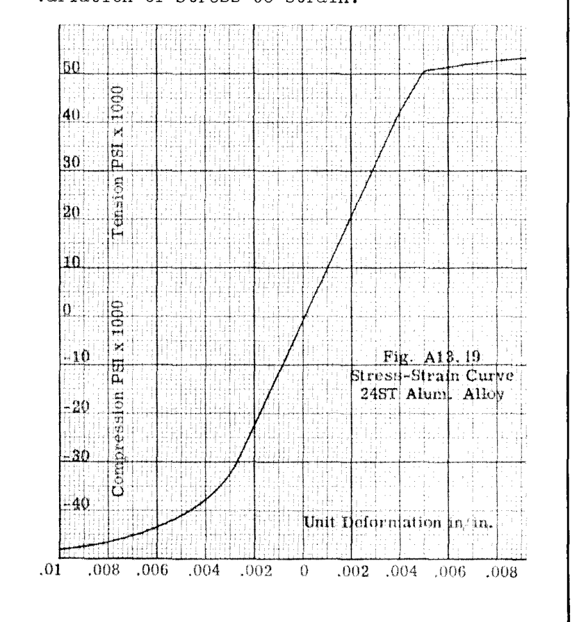

図 A13.19

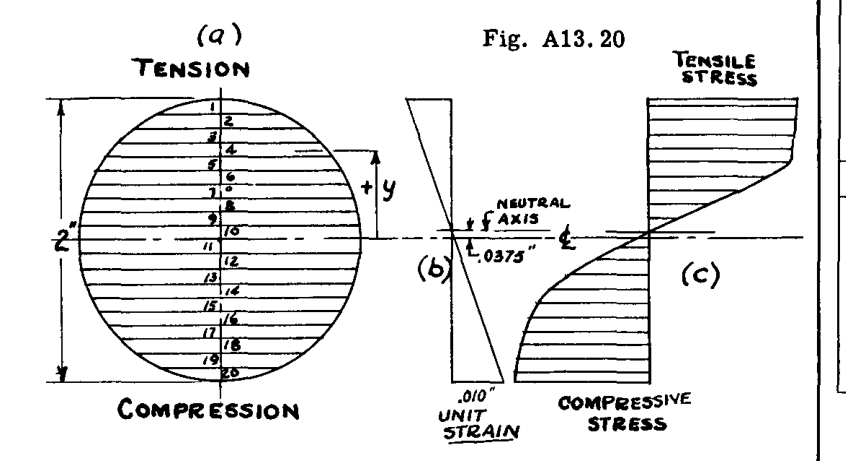

図 A13.20

### 解法

引張における応力-ひずみ線図は圧縮におけるものと異なるため（図 A13.19 参照）、丸棒が対称形状であるという事実にかかわらず、中立軸は丸棒の図心軸と一致しない。したがって、中立軸の位置を直接解決することができないため、解決方法は試行錯誤の方法となる。図 A13.20 の（b）において、中立軸は棒の中心線軸より $0.0375\text{ インチ}$ 上方に想定されている。図 A13.19 の応力-ひずみ曲線の観察から、それは引張側に想定された。

図 A13.19 は、非弾性範囲における与えられたひずみに対して、得られる引張応力が得られる圧縮応力よりも高く、さらに内部平衡から、断面上の全引張応力は全圧縮応力に等しくなければならないことを示している。

記載された問題は、 $0.01$ の圧縮単位ひずみが破損を引き起こしたと仮定した。したがって、図（b）は、非弾性範囲における曲げ後も平面は平面のままであるため、破損直前の梁のひずみの状態を示している。表 A13.2 は、与えられたひずみ条件下で発生する内部抵抗モーメントを決定するための詳細な計算を示している。

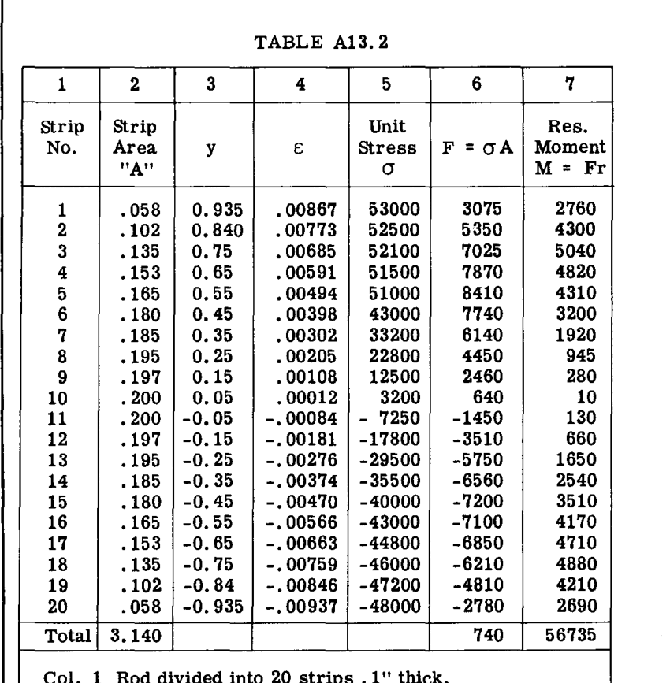

TABLE A13.2

$0.01$ の最大単位圧縮ひずみをとると、図 A13.19 から対応する応力は $48500\text{ psi}$ であることがわかる。この応力を梁公式の破損応力として使用すると、

$$M = \frac{\sigma I}{c}$$

が得られ、次のようになる。

$$M = 48500 \times 0.785 = 38000\text{ in. lbs.}$$

$$\left(0.785 = \text{丸棒の} \frac{I}{c} = \frac{\pi r^3}{4}\right)$$

したがって、極端な繊維における同じ破壊応力を使用すると、線形応力-ひずみ関係に基づく梁公式は、真の強度 $56735$ と比較して $38000$ の極限曲げ強度を与えるか、わずか67パーセントにすぎない。

図 A13.20 の（c）は、断面上の真の応力分布を示しており、三角分布が使用される場合よりも抵抗モーメントが高くなる理由を説明している。

構造用形状の極限曲げ強度の問題は、第II巻で詳細に説明されている。

## A13.11 曲がり梁、弾性範囲内の応力

この章の前の項で導出された方程式は、直線である梁のためのものであった。したがって、図 A13.21 において、導出に使用された長さ要素（L）は梁の深さ全体にわたって一定であった。したがって、ひずみ（ $\Delta L / L$ ）は、線形変化を持つ $\Delta L$ に直接比例していた。

曲がり梁では、曲げ後も平面断面が平面のままであるという仮定は依然として適用されるが、図 A13.22 に示すように、曲率のために曲がり梁の梁セグメントは梁の深さ全体にわたって等しい幅を持つことができない。言い換えれば、セグメントの長さは内側エッジ（ $L_i$ ）よりも外側エッジ（ $L$ ）の方が大きくなる。

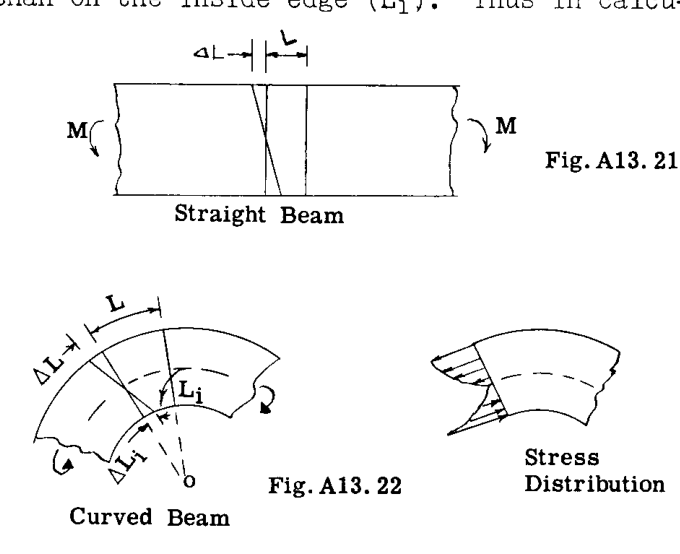

図 A13.21, 図 A13.22

したがって、梁の深さ全体のひずみ分布を計算する際、ある点における長さの変化 $\Delta L$ は、その点におけるセグメントの幅で割らなければならない。したがって、平面断面が平面のままであっても、断面全体のひずみ分布は線形にはならない。任意の点におけるセグメントの幅はセグメントの曲率半径に直接比例するため、セグメント上の点におけるひずみは曲率半径に反比例する。これにより、図 A13.22 に示すような双曲線タイプのひずみ分布が得られ、ひずみが弾性限度内であれば、応力分布も同様になる。双曲線応力分布に基づく梁公式の展開は、高等材料力学に関するほとんどの本に記載されているため、ここでは繰り返さない。

しかし、直線の梁公式によって得られた応力に掛け合わせて曲がり梁の真の応力を得ることができる補正係数Kの形で、梁の曲率の影響を表すのが便利である。したがって、曲がり梁の場合、最大応力は次の式から計算できる。

$$\sigma = K \frac{M c}{I} \quad \text{--- (19)}$$

表 A13.3 は、様々な梁断面形状および梁の曲率半径に対するKの値を示している。表は、かなり急な曲率に対してのみ補正が顕著であることを示している。一般に、飛行機の胴体リングやフレームでは、曲率の影響は無視できる。しかし、飛行機の構造には、その部品が応力への影響を極めて重要にするほどの曲率を含む、フィッティングや機械的構造ユニットがしばしば存在する。曲げにおける曲がったユニットの内側エッジへの応力の集中は、ユニットの疲労強度にかなり影響を与える可能性があるため、曲率の起こりうる影響の考慮は設計手順の通常の一部であるべきである。

非弾性または塑性応力範囲では、非弾性範囲における材料の剛性は弾性応力範囲におけるよりもはるかに低く、応力が増加するにつれてかなり緩やかに変化するため、梁の曲率の影響はかなり小さくなるはずである。

## A13.12 問題

1. 図 A13.23 は、12個のストリンガーを持つ単一セル梁の断面を示している。壁とウェブは曲げに対して効果がないと仮定する。梁公式を使用して、各ストリンガーの荷重を計算せよ。また、内部抵抗モーメントを外部曲げモーメントに等しくすることによって、ストリンガー荷重を計算せよ。各ストリンガーの面積は同じで $0.1\text{ sq. in.}$ であり、加えられた曲げモーメント $M_x = -100,000\text{ in. lb.}$ である。

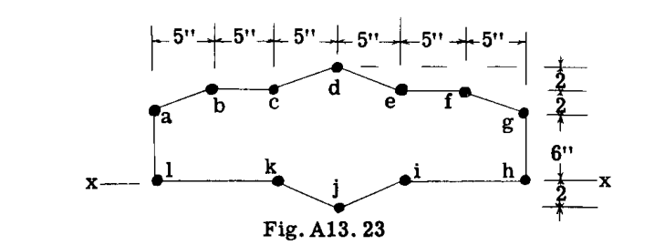

図 A13.23

2. 問題（1）と同じであるが、外部曲げモーメントを $M_y = 200,000\text{ in. lb.}$ に変更せよ。
3. 図 A13.24 は、4つのストリンガーを持つ梁断面を示している。ウェブと壁は曲げに対して効果がないと仮定する。ストリンガー面積は図の（）内に示されている。外部から加えられた曲げモーメントは以下の通りである：

$$M_x = -500,000\text{ in. lb.} \quad \text{および} \quad M_y = 200,000\text{ in. lb.}$$

この章で説明された3つの方法すべてによって、4つのストリンガーすべてにおける応力を求めよ。

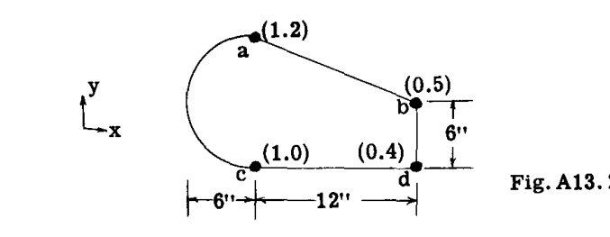

図 A13.24

4. 図 A13.25 に示すゼット断面は、 $M_x = 500\text{ in. lb.}$ および $M_y = 2000\text{ in. lb.}$ の曲げモーメントを受ける。点a, b, c, dにおける曲げ応力を求めよ。

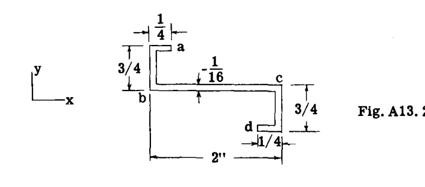

図 A13.25

5. 図 A13.26 は、3つの異なる材料で構成された梁断面を示している。 $M_x = 80,000\text{ in. lb.}$ の曲げモーメントによる、梁の上部および下部における応力を求めよ。
- $E_{\text{Mag.}} = 6.5 \times 10^6$
- $E_{\text{Steel}} = 29 \times 10^6$
- $E_{\text{Alum.}} = 10.5 \times 10^6$

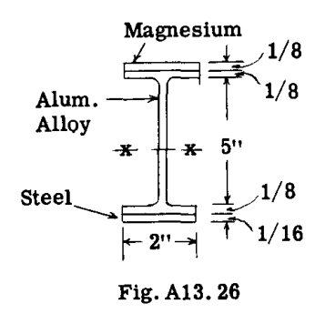

図 A13.26

6. 図 A13.26 は、ラベルA, B, Cで示された3種類の木材を接着して複合梁を形成した木製梁の断面を示している。梁が $M_x = 75000\text{ in. lb.}$ の曲げモーメントを受ける場合、梁の上端における曲げ応力の強度を求めよ。また、部分BおよびCにおける全端荷重を求めよ。
- A = トウヒ、 $E = 1,300,000\text{ psi}$
- B = カエデ、 $E = 1,500,000\text{ psi}$
- C = モミ、 $E = 1,600,000\text{ psi}$

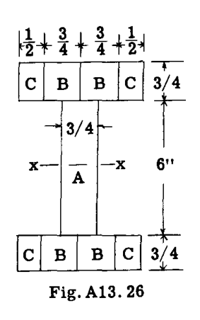

図 A13.26

7. 図 A13.27 は、3つの異なる梁断面を示している。これらは、応力-ひずみ線図が 図 A13.19 にプロットされたものと同じであるアルミ合金で作られている。最大圧縮ひずみが $0.01\text{ in./in.}$ に制限されている場合、極限内部抵抗モーメントを決定せよ。上部が圧縮されていると仮定する。公式 $M = \sigma_b I/c$ （ここで $\sigma_b$ は単位ひずみが $0.01$ のときの圧縮応力）で得られた結果と比較せよ。

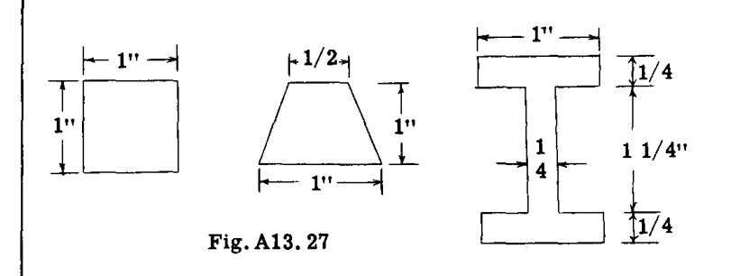

図 A13.27

8. 図 A13.28 は、2つの $500\text{ lb.}$ 荷重を支持する曲がり梁を示している。梁の断面がセクション1、2、および3で示される3つの異なる方法で作られているときの、点CおよびC’における曲げ応力を求めよ。表 A13.3を使用せよ。

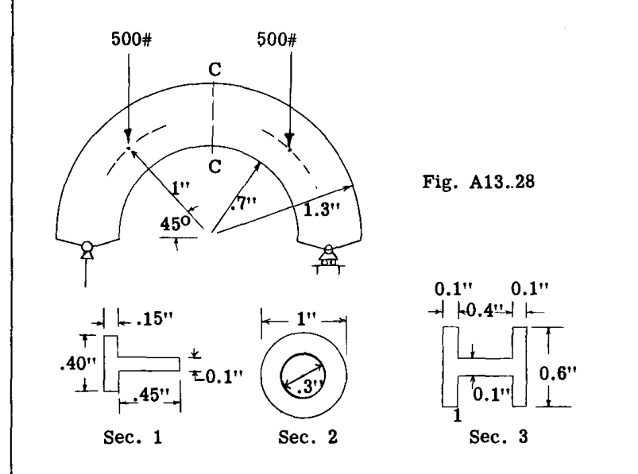

図 A13.28

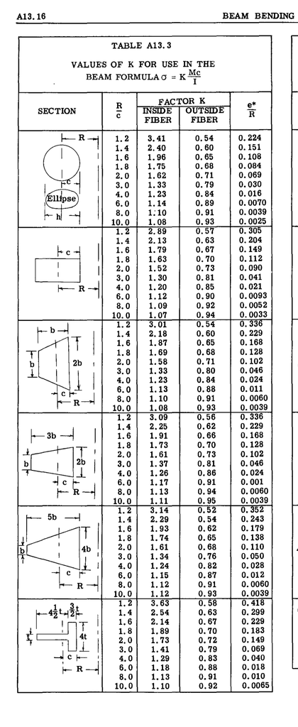

TABLE A13.3

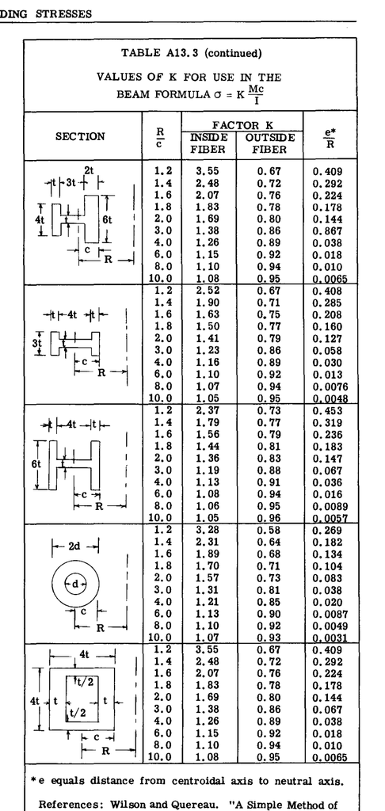

TABLE A13.3 (continued)

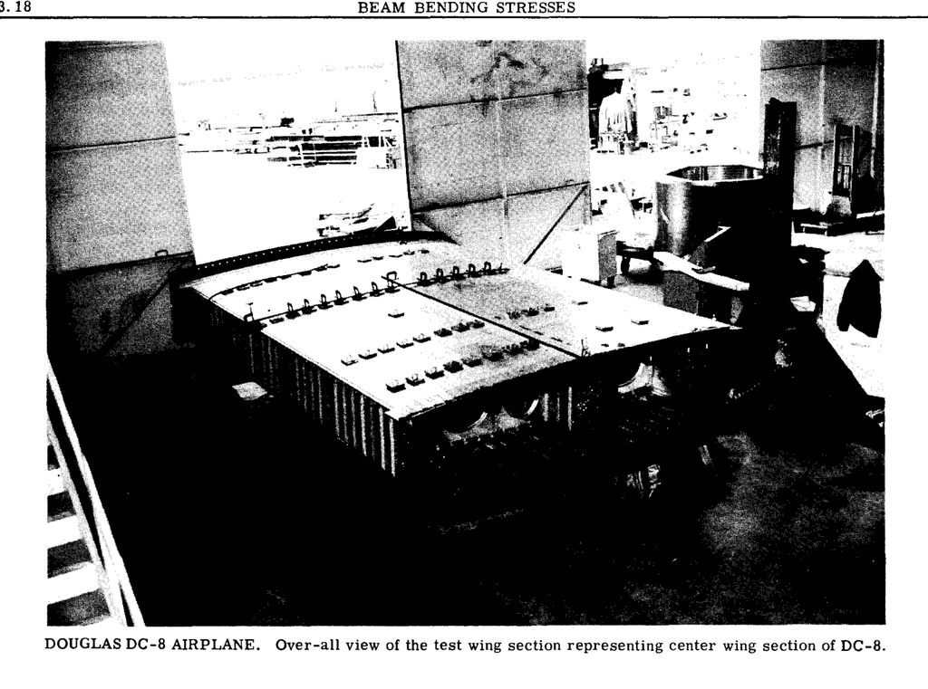

DOUGLAS DC-8 AIRPLANE

ダグラス DC-8 航空機。DC-8の主翼中央セクションを表す試験翼セクションの全体像。

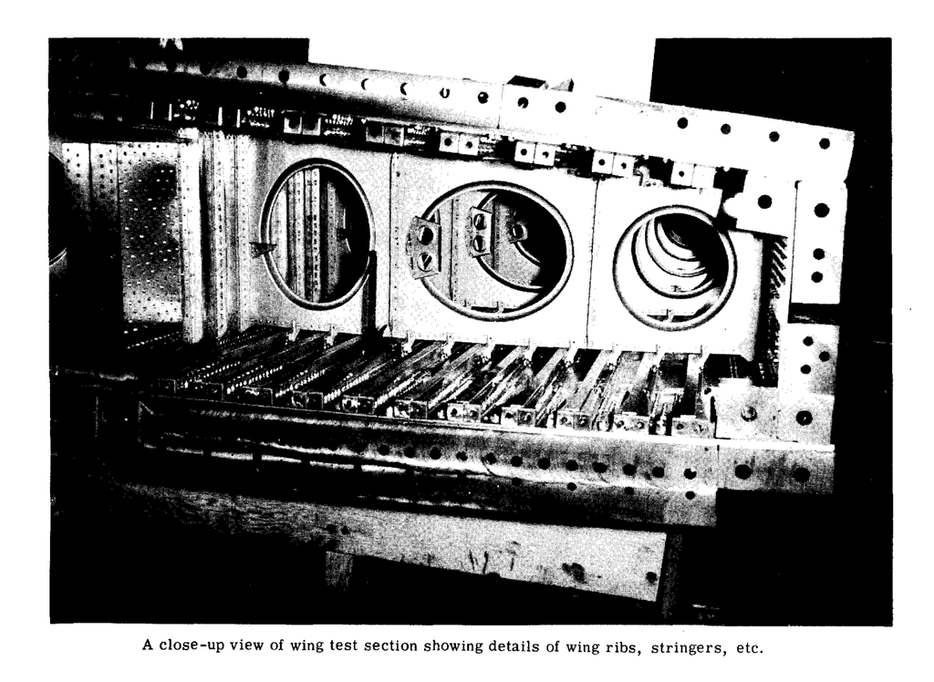

A close-up view of wing test section

翼リブ、ストリンガーなどの詳細を示す、試験翼セクションのクローズアップ。